# Numeric Summaries and Uncertainty (Intro Stats Review)

Ryan Miller

## Summarizing Data

- Modern data are often too complex to understand by inspection
- The table below displays the solubility of 1267 chemical compounds along with some attributes analytically derived from their structures
- Question: Just by looking, can you determine how solubility is related to chemical structure?

| Solubility | NumAtoms | NumNonHAtoms | NumBonds | NumNonHBonds | NumMultBonds | NumRotBonds | NumDblBonds | NumAromaticBonds | NumHydrogen | NumCarbon | NumNitrogen | NumOxygen | NumSulfer | NumChlorine | NumHalogen | NumRings | HydrophilicFactor | SurfaceArea1 | SurfaceArea2 |
| --- | --- | --- | --- | --- | --- | --- | --- | --- | --- | --- | --- | --- | --- | --- | --- | --- | --- | --- | --- |
| 0.93 | 8 | 5 | 7 | 4 | 1 | 0 | 1 | 0 | 3 | 2 | 0 | 2 | 0 | 1 | 1 | 0 | 0.492 | 37.30 | 37.30 |
| 0.85 | 13 | 6 | 12 | 5 | 1 | 2 | 1 | 0 | 7 | 3 | 1 | 2 | 0 | 0 | 0 | 0 | 1.317 | 52.32 | 52.32 |
| 0.81 | 14 | 8 | 14 | 8 | 6 | 0 | 0 | 6 | 6 | 6 | 0 | 2 | 0 | 0 | 0 | 1 | 0.846 | 40.46 | 40.46 |
| 0.74 | 19 | 7 | 19 | 7 | 0 | 0 | 0 | 0 | 12 | 5 | 2 | 0 | 0 | 0 | 0 | 1 | 0.984 | 24.06 | 24.06 |
| 0.61 | 15 | 9 | 15 | 9 | 7 | 1 | 1 | 6 | 6 | 6 | 2 | 1 | 0 | 0 | 0 | 1 | 0.843 | 55.98 | 55.98 |
| 0.58 | 8 | 4 | 7 | 3 | 1 | 1 | 1 | 0 | 4 | 2 | 0 | 2 | 0 | 0 | 0 | 0 | -0.431 | 26.30 | 26.30 |
| 0.57 | 8 | 4 | 7 | 3 | 2 | 1 | 2 | 0 | 4 | 3 | 0 | 1 | 0 | 0 | 0 | 0 | -0.646 | 17.07 | 17.07 |
| 0.56 | 13 | 5 | 13 | 5 | 0 | 0 | 0 | 0 | 8 | 4 | 0 | 1 | 0 | 0 | 0 | 1 | -0.719 | 9.23 | 9.23 |
| 0.52 | 13 | 5 | 12 | 4 | 1 | 1 | 1 | 0 | 8 | 4 | 0 | 1 | 0 | 0 | 0 | 0 | -0.719 | 17.07 | 17.07 |
| 0.45 | 17 | 8 | 17 | 8 | 6 | 0 | 0 | 6 | 9 | 7 | 1 | 0 | 0 | 0 | 0 | 1 | -0.828 | 12.89 | 12.89 |
| 0.40 | 17 | 8 | 17 | 8 | 6 | 0 | 0 | 6 | 9 | 7 | 1 | 0 | 0 | 0 | 0 | 1 | -0.828 | 12.89 | 12.89 |
| 0.36 | 28 | 14 | 30 | 16 | 3 | 0 | 3 | 0 | 14 | 11 | 2 | 1 | 0 | 0 | 0 | 3 | -0.235 | 34.03 | 34.03 |
| 0.22 | 15 | 7 | 14 | 6 | 2 | 2 | 2 | 0 | 8 | 5 | 0 | 2 | 0 | 0 | 0 | 0 | -0.668 | 34.14 | 34.14 |
| 0.08 | 18 | 6 | 17 | 5 | 0 | 1 | 0 | 0 | 12 | 5 | 0 | 1 | 0 | 0 | 0 | 0 | 0.004 | 20.23 | 20.23 |
| 0.07 | 16 | 8 | 16 | 8 | 6 | 1 | 0 | 6 | 8 | 6 | 2 | 0 | 0 | 0 | 0 | 1 | 1.882 | 38.05 | 38.05 |
| 0.02 | 14 | 10 | 15 | 11 | 11 | 0 | 0 | 11 | 4 | 6 | 4 | 0 | 0 | 0 | 0 | 2 | -0.576 | 51.56 | 51.56 |
| 0.00 | 13 | 7 | 13 | 7 | 6 | 0 | 0 | 6 | 6 | 6 | 0 | 1 | 0 | 0 | 0 | 1 | -0.088 | 20.23 | 20.23 |
| -0.01 | 13 | 5 | 12 | 4 | 1 | 2 | 1 | 0 | 8 | 4 | 0 | 1 | 0 | 0 | 0 | 0 | -0.719 | 17.07 | 17.07 |
| -0.07 | 12 | 7 | 12 | 7 | 5 | 0 | 0 | 5 | 5 | 4 | 1 | 2 | 0 | 0 | 0 | 1 | 0.180 | 46.26 | 46.26 |
| -0.12 | 17 | 11 | 18 | 12 | 11 | 0 | 0 | 11 | 6 | 7 | 4 | 0 | 0 | 0 | 0 | 2 | -0.614 | 51.56 | 51.56 |
| -0.17 | 23 | 11 | 23 | 11 | 0 | 0 | 0 | 0 | 12 | 6 | 0 | 5 | 0 | 0 | 0 | 1 | 3.857 | 101.15 | 101.15 |
| -0.29 | 9 | 5 | 8 | 4 | 1 | 0 | 0 | 0 | 4 | 3 | 1 | 0 | 0 | 1 | 1 | 0 | -0.539 | 23.79 | 23.79 |
| -0.38 | 21 | 7 | 20 | 6 | 0 | 2 | 0 | 0 | 14 | 6 | 0 | 1 | 0 | 0 | 0 | 0 | -0.088 | 20.23 | 20.23 |
| -0.38 | 16 | 8 | 16 | 8 | 6 | 0 | 0 | 6 | 8 | 6 | 2 | 0 | 0 | 0 | 0 | 1 | 3.032 | 52.04 | 52.04 |
| -0.39 | 21 | 7 | 20 | 6 | 0 | 2 | 0 | 0 | 14 | 6 | 0 | 1 | 0 | 0 | 0 | 0 | -0.088 | 20.23 | 20.23 |
| -0.42 | 16 | 8 | 16 | 8 | 6 | 0 | 0 | 6 | 8 | 6 | 2 | 0 | 0 | 0 | 0 | 1 | 3.032 | 52.04 | 52.04 |
| -0.44 | 19 | 7 | 19 | 7 | 0 | 0 | 0 | 0 | 12 | 6 | 0 | 1 | 0 | 0 | 0 | 1 | -0.088 | 20.23 | 20.23 |
| -0.46 | 12 | 7 | 12 | 7 | 6 | 0 | 0 | 6 | 5 | 5 | 1 | 1 | 0 | 0 | 0 | 1 | 0.046 | 33.12 | 33.12 |
| -0.48 | 43 | 22 | 46 | 25 | 7 | 5 | 1 | 6 | 21 | 17 | 1 | 4 | 0 | 0 | 0 | 4 | -0.310 | 62.30 | 62.30 |
| -0.60 | 17 | 7 | 17 | 7 | 1 | 0 | 1 | 0 | 10 | 6 | 0 | 1 | 0 | 0 | 0 | 1 | -0.802 | 17.07 | 17.07 |

[output cut: 1237 more lines]

## The Mean and Median

- In order understand large datasets, we need to summarize, but how we summarize matters!
- The **mean** and **median** are two ways of describing the “typical” data-point
  - Question: Which colored line depicts the mean? Which measure better reflects the number of nitrogen atoms of a “typical” compound in this dataset?

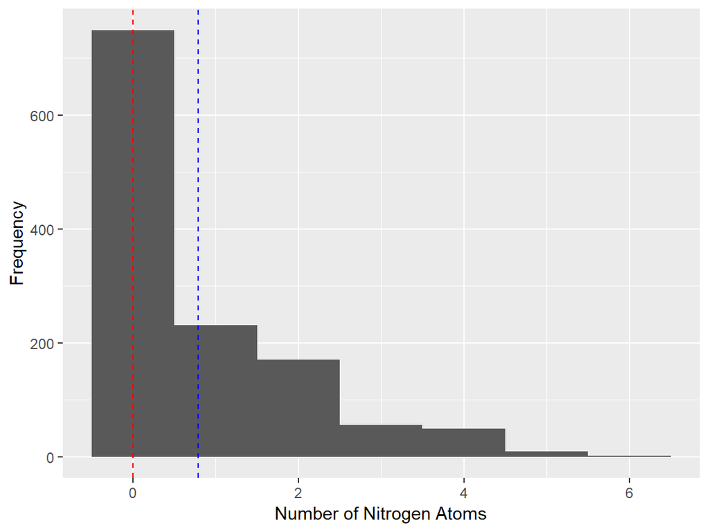

## Other Summary Statistics

- Thinking only in terms of the “typical” data-point can be dangerous, often we are interested in values that aren’t typical

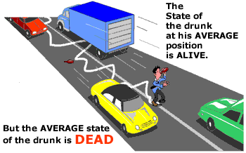

- Suppose the vehicles in the cartoon drive 2 feet from the center-line, we might consider reporting the proportion of the drunk’s positions outside of (-2, 2)
- Alternatively, if we don’t know how far the vehicles are from the center-line, we could report certain **percentiles** of the drunk’s positions
  - For example, if the 90% percentile is 1.1, this indicates 90% of the drunk’s positions are less than 1.1 feet above the center-line
  - You can find percentiles in `R` using the quantile function

```r
x <- seq(1:100)
quantile(x, probs = .1)
```

```
##  10%
## 10.9
```

```r
quantile(x, probs = .9)
```

```
##  90%
## 90.1
```

Image from “The Flaw of Averages”: [Link](https://web.stanford.edu/~savage/faculty/savage/FOA%20Index.htm)

## Variability

- Summaries of the “typical” data-point suffer from another flaw, they don’t express the variation in the data
  - The means of $x = \{2,5,7,10\}$ and $y = \{5,6,6,7\}$ are both 6, but $x$ and $y$ are clearly very different
- Means are used reported accompanied by a **standard deviation** or a **standard error**
  - Question: What’s the difference between these? (this should be review)

## Standard Deviation vs. Standard Error

- **Standard Deviation** describes the variability *of the data* - how spread out the data-points are around their mean
- **Standard Error** describes the uncertainty *of an estimate* - we might see our data as a sample representing some population, so we use sample mean is an estimate of a population characteristic
  - We may choose to use the standard error to derive a **confidence interval**
  - If the *sampling distribution* is approximately normal, we are 95% confident the population characteristic is within 1.96 standard errors of the sample estimate

[output not shown]

- Question: Based upon this table, does the solubility of a compound appear related to how many oxygen atoms it contains?

## Pairwise Associations

- With univariate summaries (like the mean), we lose any information about how the variables are related
  - This is a big deal, as most applications center around relating two or more variables
- One way of evaluating **association** between two variables (pairwise associations) is to use visualization
  - Question: Based upon the graph below, is there an association between the number of oxygen atoms and a compound’s solubility?

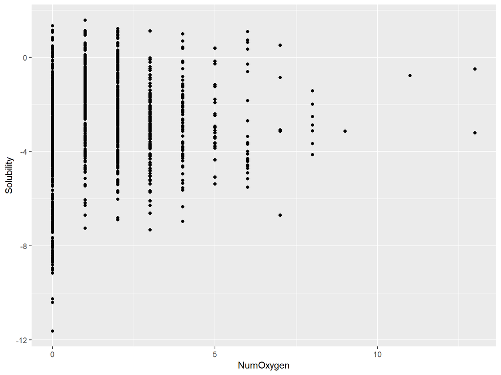

## Pairwise Associations - Correlation

- The plot tells us a lot about the association, compounds with more oxygen atoms tend to have higher solubility scores
  - But exactly how strong is this relationship?
- The **correlation coefficient** is one way of quantifying the association between two numeric variables
  - Like before, if we consider our data a sample we might report the correlation coefficient accompanied by an uncertainty measure
  - The `cor` function can be used to find correlations, the `cor.test` can be used to find accompanying confidence intervals

```r
cor(x = data$NumOxygen, y = data$Solubility)
```

```
## [1] 0.1158384
```

```r
cor.test(x = data$NumOxygen, y = data$Solubility)
```

```
##
##  Pearson's product-moment correlation
##
## data:  data$NumOxygen and data$Solubility
## t = 4.1479, df = 1265, p-value = 3.579e-05
## alternative hypothesis: true correlation is not equal to 0
## 95 percent confidence interval:
##  0.06115601 0.16982747
## sample estimates:
##       cor
## 0.1158384
```

- Question: How would you describe the relationship between these variables? Are they strongly associated? Do you think they could be unrelated?

## Conclusion and Remarks on Hypothesis Testing

- The first step in any data analysis is to learn about your variables
  - Summarization, in the form of summary statistics and/or visuals, is essential in this process
- Recognizing that most data comes with uncertainty is another critical aspect of data science/statistics
  - You consider using confidence intervals to quantify how a sample statistic might generalize to a broader population
- In this class we won’t place much empthasis on hypothesis testing, but you should be aware of it. For certain projects, hypothesis testing is a nature choice and a very useful tool